# Approximate Bayesian Computation and Insurance

## Patrick J. Laub

## Motivation

Have a random number of claims $N \sim p_N( \,\cdot\, ; \boldsymbol{\theta}_{\mathrm{freq}} )$ and the claim sizes $U_1, \dots, U_N \overset{\mathrm{i.i.d.}}{\sim} f_U( \,\cdot\, ; \boldsymbol{\theta}_{\mathrm{sev}} )$.

We aggregate them somehow, like:

- aggregate claims: $X = \sum_{i=1}^N U_i $
- maximum claims: $X = \max_{i=1}^N U_i $
- stop-loss: $X = ( \sum_{i=1}^N U_i - c )_+ $.

**Question**: Given a sample $X_1, \dots, X_n$ of the summaries, what is the $\boldsymbol{\theta} = (\boldsymbol{\theta}_{\mathrm{freq}}, \boldsymbol{\theta}_{\mathrm{sev}})$ which generated them?

**Easier question**: Given $(X_1, N_1), \dots, (X_n, N_n)$ summaries \& counts, what is $\boldsymbol{\theta})$?

## Likelihoods

For simple rv's we know their likelihood (normal, exponential, gamma, etc.).

When simple rv's are combined, the resulting thing rarely has a likelihood.

$$ X_1, X_2 \overset{\mathrm{i.i.d}}{\sim} f_X(\,\cdot\,) \Rightarrow X_1 + X_2 \sim ~ \texttt{Unknown Likelihood}! $$

For a sample of $n$ i.i.d. observations the joint likelihood is

$$ p_{\mathbf{X}}(\mathbf{x} \mid \boldsymbol{\theta}) = \prod_{i=1}^n p_{X_i}(x_i; \boldsymbol{\theta}) \,. $$

If $n$ increases, then $p_{\mathbf{X}}(\mathbf{x} \mid \boldsymbol{\theta}) = \prod \text{Small things} \overset{\dagger}{=} 0$, or just takes a long time to compute, then $\texttt{Intractable Likelihood}$!

## The statistics 'algorithm'

[figure not shown]

**Toy problem**: Flip a coin a few times and get $(X_1, X_2, X_3) = (\text{H, T, H})$; what is

$$p = \mathbb{P}(\text{Heads}) ? $$

Look at likelihood and maximise it:

$$ \boldsymbol{\theta}_{\mathrm{MLE}} = \arg\max_{\boldsymbol{\theta}} \prod_{i=1}^n p_X(X_i; \boldsymbol{\theta}) $$

Set $\boldsymbol{\theta}_{\mathrm{MLE}}$ as the solution to $$ \frac{\mathrm{d}}{\mathrm{d}\boldsymbol{\theta}} \sum_{i=1}^n \log\bigl[ p_X(X_i; \boldsymbol{\theta}) \bigr] ~ = 0 \,. $$

$$ \theta_{\mathrm{MLE}} = \arg\max_{\theta} \theta^2 (1 - \theta) = \frac{2}{3} \,.$$

## Bayes and prior distributions

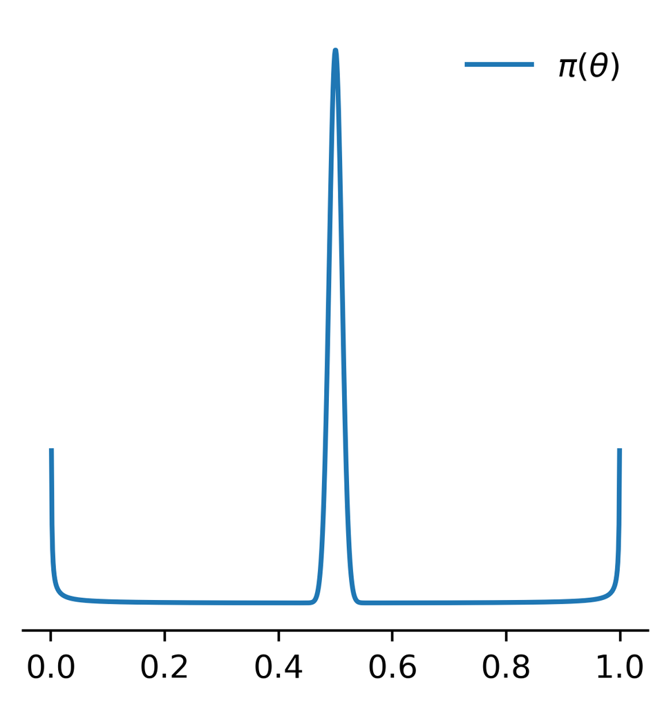

- See [Frequentists vs. Bayesians (xkcd)](https://imgs.xkcd.com/comics/frequentists_vs_bayesians.png)

## The statistics 'algorithm' continued

[figure not shown]

## Posterior distributions (when the math works)

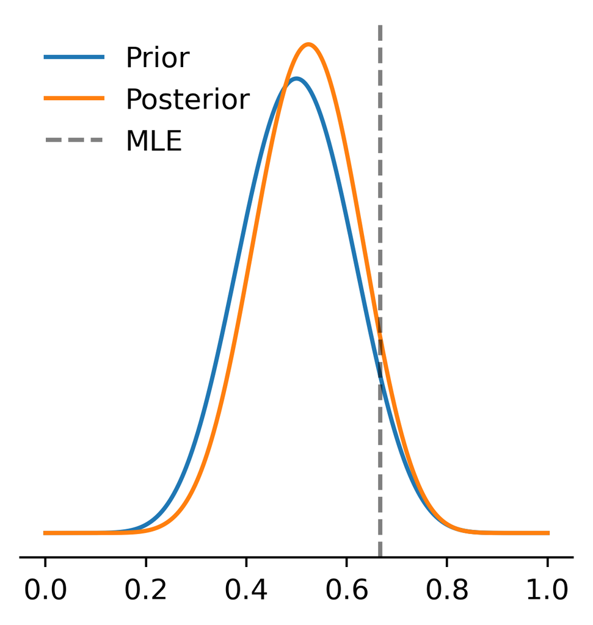

$$ \pi(\boldsymbol{\theta} \mid \mathbf{x} ) = \frac{ \pi(\boldsymbol{\theta}) \pi( \mathbf{x} \mid \boldsymbol{\theta} ) }{ \pi( \mathbf{x} ) } $$

- If we can't solve it with math.. [see](https://chi-feng.github.io/mcmc-demo/app.html#HamiltonianMC,banana)

## Markov chain Monte Carlo

[figure not shown]

## Approximate Bayesian Computation

**Example**: Flip a coin a few times and get $(X_1, X_2, X_3) = (\text{H, T, H})$; what is $\theta = \mathbb{P}(\text{Heads})$?

[video not shown]

## Exact matching algorithm

Given some observations $\boldsymbol{x}_{\text{obs}}$, repeat:

- generate a potential parameter from the prior distribution $\boldsymbol{\theta}^{\ast} \sim \pi(\boldsymbol{\theta})$;
- simulate some 'fake data' $\mathbf{x}^{\ast}$ from the model $\boldsymbol{\theta}^{\ast}$;
- if $ \mathbf{x}_{\text{obs}} = \mathbf{x}^{\ast}$, then store $\boldsymbol{\theta}^{\ast}$.

The resulting $\boldsymbol{\theta}^{\ast}$s are an i.i.d. sample from the posterior $\pi(\theta \mid \mathbf{x}_{\text{obs}})$.

## Getting an exact match of the data is hard...

[video not shown]

## Summarise the data (reduce the dimension)

[video not shown]

## Accept fake data that's close to observed data

[video not shown]

## ABC acceptance-rejection algorithm

Given some observations $\boldsymbol{x}_{\text{obs}}$, to generate $R$ samples from the posterior:

- For $i = 1$, $\dots$, $R$:
  - Repeat:
    - generate a potential parameter from the prior distribution $\boldsymbol{\theta}^{\ast} \sim \pi(\boldsymbol{\theta})$;
    - simulate some 'fake data' $\mathbf{x}^{\ast}$ from the model $\boldsymbol{\theta}^{\ast}$;
  - Until $ \lVert \mathbf{x}_{\text{obs}}-\mathbf{x}^{\ast} \rVert \leq \epsilon$
  - Store $\boldsymbol{\theta}^{\ast}_i = \boldsymbol{\theta}^{\ast}$

Inputs: $\lVert \,\cdot\, \rVert$ denotes a distance measure, and $\epsilon \ge 0$ is an acceptance threshold.

This samples from the *approximate posterior* a.k.a. the *ABC posterior*

$$ \pi_\epsilon(\boldsymbol{\theta} \mid \mathbf{x}_{\text{obs}}) \propto \pi(\theta) \times \mathbb{P}\bigl( \lVert \mathbf{x}_{\text{obs}}-\mathbf{x}^{\ast} \rVert \leq \epsilon \text{ where } \mathbf{x}^{\ast} \sim \boldsymbol{\theta} \bigr) .$$

## The 'approximate' part of ABC

[video not shown]

## Taking a bad approximation and making a better one

Say we have samples from a bad approximation $\pi_3(\boldsymbol{\theta} \mid \mathbf{x}_{\text{obs}})$ and want to improve them to be samples from a better approximation $\pi_1(\boldsymbol{\theta} \mid \mathbf{x}_{\text{obs}})$?

- Fit a kernel density estimate $K$ to the samples from the bad distribution $\pi_3(\boldsymbol{\theta} \mid \mathbf{x}_{\text{obs}})$
- For $i = 1$, $\dots$, $R$:
  - Repeat:
    - generate a potential parameter $\boldsymbol{\theta}^{\ast}$ from the KDE $K$;
    - simulate some 'fake data' $\mathbf{x}^{\ast}$ from the model $\boldsymbol{\theta}^{\ast}$;
  - Until $ \lVert \mathbf{x}_{\text{obs}}-\mathbf{x}^{\ast} \rVert \leq 1$
  - Store $\boldsymbol{\theta}^{\ast}_i = \boldsymbol{\theta}^{\ast}$ along with a **weight** $w_i = \frac{ \pi(\boldsymbol{\theta}^{\ast}) }{ K(\boldsymbol{\theta}^{\ast}) }$

Repeat this to get the ABC *Sequential Monte Carlo* algorithm, a.k.a. *Population Monte Carlo*.

## Dependent Poisson - Exponential

- frequency $N \sim \mathsf{Poisson}(\lambda=4)$,
- severity $U_i \mid N \sim \mathsf{DepExp}(\beta=2, \delta=0.2)$, defined as $$ U_i \mid N \sim \mathsf{Exp}(\beta\times \mathrm{e}^{\delta N}), $$
- summation summary $X = \sum_{i=1}^N U_i $
- sample size = 50 and 250

[figure not shown]

## Negative-Binomial - Weibull

- frequency $N \sim \mathsf{NegBin}(4, \frac23)$,
- severity $U_i \sim \mathsf{Weibull}(\frac13, 1)$,
- global stop-loss summary $X = ( \sum_{i=1}^N U_i - 6 )_+$

[figure not shown]

If we observe $(N_1, X_1), \dots, (N_n, X_n)$, the **frequency** and the summaries of the **severities**

[figure not shown]

## Negative-Binomial - Gamma on same data

## Model selection

Given some observations $\boldsymbol{x}_{\text{obs}}$, to generate $R$ samples from the posterior:

- For $i = 1$, $\dots$, $R$:
  - Repeat:
    - generate a potential parameter from the prior distribution $\boldsymbol{\theta}^{\ast} \sim \pi(\boldsymbol{\theta})$;
    - simulate some 'fake data' $\mathbf{x}^{\ast}$ from the model $\boldsymbol{\theta}^{\ast}$;
  - Until $ \lVert \mathbf{x}_{\text{obs}}-\mathbf{x}^{\ast} \rVert \leq \epsilon$
  - Store $\boldsymbol{\theta}^{\ast}_i = \boldsymbol{\theta}^{\ast}$

Inputs: $\lVert \,\cdot\, \rVert$ denotes a distance measure, and $\epsilon \ge 0$ is an acceptance threshold.

This samples from the *approximate posterior* a.k.a. the *ABC posterior*

$$ \pi_\epsilon(\boldsymbol{\theta} \mid \mathbf{x}_{\text{obs}}) \propto \pi(\theta) \times \mathbb{P}\bigl( \lVert \mathbf{x}_{\text{obs}}-\mathbf{x}^{\ast} \rVert \leq \epsilon \text{ where } \mathbf{x}^{\ast} \sim \boldsymbol{\theta} \bigr) .$$

## Problems

## - Unidentifiability problems (Poisson / Exponential)